# First Steps in the tidyverse

Mirjam Eiswirth, PhD candidate, Linguistics and English Language, University of Edinburgh, Twitter: @MirjamIce

20 February 2019

Today, I’d like to present my first R project, and what the code can look like using the tidyverse, specifically dplyr(), ggplot2(), and lubridate(). I will present some snippets of base-R code I wrote for the original project to show how much easier, more intuitive, and more concise tidyverse code is.

When I started learning about R and statistics, this was my general approach to what I classed as “numbers”:

[figure not shown]

“let’s use them to build narratives!”

So if you are a bit weary of numbers and programming, here is the story of how I got started - and actually genuinely excited about *including* the numbers in the stories we tell.

The main lesson for me in this process, that I want to share:

- get data you are genuinely excited about
- ask questions you really want to know the answer to
- do something that you feel will make a difference

These points will most likely apply the more strongly the less you feel like a “numbers person”. So let’s get started by importing the core packages that make working with R a lot more intuitive and enjoyable for beginners (and probably also for advanced users…).

```r
library(tidyverse)
```

```r
# the tidyverse automatically loads the core packages I will be drawing on:
  # ggplot2
  # dplyr
  # tidyr
# as well as some I won't draw on here
  # readr
  # purrr
  # tibble
  # stringr
  # forcats

library(lubridate) # this is a tidyverse-affiliated package to work with dates and date-times
library(naniar) # contains the function replace_na(); complement to na_replace()
```

# Practical challenge/research question

My practical challenge I tried to address was my own Type 1 Diabetes Management:

1. *Observed*: high glucose variability
2. *Goal*: find out what predicts glucose variability in order to reduce it

If you would like some more medical background, a write-up of this analysis and the results is published here as a case report:

> Eiswirth, M., Clark, E., & Diamond, M. (2018). Low carbohydrate diet and improved glycaemic control in a patient with type one diabetes, Endocrinology, Diabetes & Metabolism Case Reports, 2018, 18-0002. https://edm.bioscientifica.com/view/journals/edm/2018/1/EDM18-0002.xml

If you would like some basic info about Type 1 Diabetes, take a look at this video: https://www.diabetes.org.uk/diabetes-the-basics/what-is-type-1-diabetes

The data I will be working with are from 2016, and I will break them down into a “before” and “after” subset. We can think of these as an “observation” and an “intervention” group.

There are a lot of more or less quantificable details to factor in when trying to predict glucose variability (and calculating how much insulin or carbs are needed to get to a certain glucose reading). A fairly comprehensive overview is the carb counting overview slide the Edinburgh Royal Infirmary Diabetes team have put together for their patients:

[figure not shown]

I decided to focus on the following factors:

- stress (rather clunkily operationalised as weekend vs week)
- menstrual cycle
- amount of exercise in any given day, measured in kcal_burned
- amount of carbs (as macronutrient ratio)

## Loading and inspecting the data

Load the data from the local source (saved in the same folder, so no need to give long path)

### loading

```r
diabetes <- read.csv(file = "2016_Diabetes.csv")
```

### column names

Get an overview over the column names - what are the variables in this dataset?

```r
colnames(diabetes)
```

```
##  [1] "Day"                    "time"
##  [3] "time_converted"         "glucose_reading"
##  [5] "bolus"                  "bolus_duration_minutes"
##  [7] "basal_percent"          "corrective"
##  [9] "kh_intake"              "kcal_intake"
## [11] "exercise_type"          "duration"
## [13] "kcal_burned"            "distance_km"
## [15] "day_type"               "cycle_day"
## [17] "comments"               "protein"
## [19] "comment_2"
```

The first columns in the data frame give the date and time, and because I had no idea how to work with date-times I also added a column I called “time_converted”.

Then follow columns with information about glucose level and insulin given (different categories, related to different reasons for the insulin). “kh_intake” and “kcal_intake” contain information about carbs and calories I had at specific times, and then I have columns with information about exercise: type, duration, calories burned, for cardio the distance. This is followed by information on the kind of day, and on hormonal patterns, and two “comments” fields. Later on, I added a column “protein” to capture macronutrient-intake in more detail.

### look at what’s in the columns: head()

```r
head(diabetes)
```

```
##          Day     time time_converted glucose_reading bolus
## 1 2016-03-22 07:00:00           7.00       12.277778    NA
## 2 2016-03-22 07:20:00           7.33              NA   5.5
## 3 2016-03-22 08:00:00           8.00              NA    NA
## 4 2016-03-22 09:30:00           9.50        6.833333    NA
## 5 2016-03-22 12:36:00          12.55        6.444444    NA
## 6 2016-03-22 13:10:00          13.20              NA   6.0
##   bolus_duration_minutes basal_percent corrective kh_intake kcal_intake
## 1                      1           100        2.6         0           0
## 2                      1           100         NA        48         400
## 3                      1           100         NA         0           0
## 4                      1           100         NA        24         180
## 5                      1           100         NA         0         100
## 6                      1           100         NA        36         450
##   exercise_type duration kcal_burned distance_km day_type cycle_day
## 1          <NA>        0           0           0  workday        22
## 2          <NA>        0           0           0  workday        22
## 3        cardio       35         380           3  workday        22
## 4          <NA>        0           0           0  workday        22
## 5          <NA>        0           0           0  workday        22
## 6          <NA>        0           0           0  workday        22
##   comments protein comment_2
## 1     <NA>      NA      <NA>
## 2     <NA>      NA      <NA>
## 3     <NA>      NA      <NA>
## 4     <NA>      NA      <NA>
## 5     <NA>      NA      <NA>
## 6     <NA>      NA      <NA>
```

### get a summary of the columns

```r
summary(diabetes)
```

```
##          Day             time      time_converted  glucose_reading
##  2016-08-24:  46   13:00:00:  77   Min.   : 0.01   Min.   : 2.200
##  2016-08-22:  38   12:00:00:  67   1st Qu.: 9.66   1st Qu.: 5.167
##  2016-10-15:  35   18:00:00:  67   Median :14.00   Median : 6.800
##  2016-08-23:  34   08:00:00:  66   Mean   :14.03   Mean   : 7.509
##  2016-08-25:  34   17:00:00:  66   3rd Qu.:18.50   3rd Qu.: 9.167
##  (Other)   :4460   (Other) :4304   Max.   :24.00   Max.   :21.611
##  NA's      :   8   NA's    :   8   NA's   :8       NA's   :1633
##      bolus        bolus_duration_minutes basal_percent      corrective
##  Min.   : 0.100   Min.   :  1.00         Min.   :  0.00   Min.   :0.200
##  1st Qu.: 1.000   1st Qu.:  1.00         1st Qu.:100.00   1st Qu.:0.600
##  Median : 2.000   Median :  1.00         Median :100.00   Median :1.000
##  Mean   : 2.682   Mean   : 12.49         Mean   : 98.44   Mean   :1.411
##  3rd Qu.: 4.000   3rd Qu.:  1.00         3rd Qu.:100.00   3rd Qu.:2.000
##  Max.   :16.000   Max.   :480.00         Max.   :125.00   Max.   :6.600
##  NA's   :2942     NA's   :8              NA's   :8        NA's   :3976
##    kh_intake       kcal_intake     exercise_type     duration
##  Min.   :  0.00   Min.   :  0.0   cardio  : 448   Min.   :  0.0
##  1st Qu.:  0.00   1st Qu.:  0.0   cycling :   2   1st Qu.:  0.0
##  Median :  0.00   Median :  0.0   massage :   1   Median :  0.0
##  Mean   :  7.49   Mean   :105.3   swimming:   1   Mean   :  3.9
##  3rd Qu.:  7.00   3rd Qu.:150.0   weights :   3   3rd Qu.:  0.0
##  Max.   :100.00   Max.   :850.0   NA's    :4200   Max.   :360.0
##  NA's   :8        NA's   :8                       NA's   :8
##   kcal_burned       distance_km             day_type      cycle_day
##  Min.   :   0.00   Min.   :  0.0000   Akademie  : 301   Min.   : 1.00
##  1st Qu.:   0.00   1st Qu.:  0.0000   conference:  31   1st Qu.: 7.00
##  Median :   0.00   Median :  0.0000   holiday   : 223   Median :15.00
##  Mean   :  32.24   Mean   :  0.3425   travel    :  78   Mean   :14.45
##  3rd Qu.:   0.00   3rd Qu.:  0.0000   weekend   : 982   3rd Qu.:21.50
##  Max.   :1265.00   Max.   :100.0000   workday   :3032   Max.   :28.00
##  NA's   :8         NA's   :8          NA's      :   8   NA's   :8
##           comments       protein
##  get up       :  70   Min.   : 1.00
##  set change   :  30   1st Qu.: 5.00
##  cold symptoms:  23   Median :14.00
##  change set   :  19   Mean   :16.73
##  travel day   :  19   3rd Qu.:24.00
##  (Other)      : 166   Max.   :60.00
##  NA's         :4328   NA's   :4450
##                                   comment_2
##  stressed                              :  55
##  cold symptoms                         :  24
##  change set                            :   3
##  from here, insulin absorbed unreliably:   1
##  hematoma at old injection site!       :   1
##  (Other)                               :   8
##  NA's                                  :4563
```

## Pre-processing the data

Now that we have seen what the individual columns contain, we can change day and time to date-time formats we can work with, and drop the clunky time_converted manual column.

We also want to replace 0 with NA in a number of columns (bolus, bolus_duration, kh_intake, kcal_intake, duration, kcal_burned, distance_km) because that is what they should logically be.

There are several neat tidyverse() functions that I will use to do this

- lubridate() functions
- ymd() and
- hms(),
- tidyverse() functions
- mutate(),
- select(),
- subset(),
- sum(),
- recode() (actually, I don’t need to use that here, but it’s a really awesome function)
- case_when() (another awesome function I had to mention, even though I don’t use it here)

I will also create some additional variables that I will use later on. Here, let’s just take them as a nice example of how we can do maths within mutate() and how we can add and multiply vectors

```r
data_2016 <- diabetes%>%
  mutate(Day = ymd(Day),#change Day and time to usable formats with lubridate()
         time = hms(time))%>%
 replace_with_na_at(.vars = c("bolus",
                               "bolus_duration",
                               "kh_intake",
                               "kcal_intake",
                               "duration",
                               "kcal_burned",
                               "distance_km"),
                     condition = ~.x == 0)%>% # replace the 0 with NA where appropriate
  select(-time_converted)%>% #drop the unnecessary column, by deselecting it
  group_by(Day)%>%
  mutate(daily_mean = mean(na.exclude(glucose_reading)), #calculate the daily mean
         daily_sd = sd(na.exclude(glucose_reading)), #calculate the daily standard deviation
         total_daily_carbs = sum(na.exclude(kh_intake)), #calculate the sum of carbs eaten on any given day
         total_daily_kcal = sum(na.exclude(kcal_intake)), #calculate the total daily calorie intake
         carb_ratio = ((total_daily_carbs*4)/total_daily_kcal)*100,
         total_kcal_burned = sum(na.exclude(kcal_burned))) #calculate the percentage of calories derived from carbs on any given day)
```

Note the difference between mutate() and summarise(), which is extremely useful:

- group_by() in combination with mutate() adds the new value (here mean glucose, standard deviation, total carbs, total calories, and carb ratio) onto the existing data frame as additional columns
- group_by() followed by summarise() creates a reduced data frame with only one entry per day (this is what I did initially, which meant I had to chose between the full dataset and the summary dataset for plotting)

Here is an impression of what this looked like when I tried to do it in base R:

#### Dates without lubridate()

```r
diabetes$Day <- as.numeric(as.character(diabetes$Day))
```

This does not look too bad, BUT working with dates as numbers and not as dates has implications for how we can plot them - working with datetimes in lubridate() is much easier.

All of the conversions above would have had to be done in base R following the structure we have just seen for converting “Day” to a numeric variable, which means far more lines of code than with dplyr() in the tidyverse.

#### replacing 0 with NA

```r
diabetes$bolus[diabetes$bolus == "0"] <- NA
diabetes$corrective[diabetes$corrective == "0"] <- NA
diabetes$kh_intake[diabetes$kh_intake == "0"] <- NA
diabetes$duration[diabetes$duration == "0"] <- NA
```

these are just some examples of the columns containing 0 that I recoded to NA with replace_with_na_at() from naniar()

### create a pre- and post-change subset

Because I implemented a change starting on 1 August 2016 based on what I learned from the data collected until the end of July 2016, I will create two data frames that we can work with separately.

```r
pre_change_2016 <- data_2016%>%
  subset(Day <= ymd(20160731))#subset to the data collected up to the end of July (NOTE: theoretically this should work with "filter", but this seems to conflict with lubridate())

post_change <- data_2016%>%
  subset(Day >= ymd(20160801)) #subset to the data collected from the 1st of August
```

#### another example for comparison: re-coding/subsetting before subset()

```r
diabetes$lifestyle_change <- NA
diabetes$lifestyle_change[diabetes$Day <= 20160731] <- "before"
diabetes$lifestyle_change[diabetes$Day >= 20160801] <- "after"
diabetes$lifestyle_change <- as.factor(diabetes$lifestyle_change)
```

## ggplot2()

ggplot2() is a wonderful visualisation tool. We can “pipe” things into it, which means that we can seamlessly link data preparation and visualisations.

### The logic of layering

Let’s look at how layering works by plotting glucose readings per day over time. I want the plot to have the following properties:

- x-axis = time
- y-axis = glucose reading in mmol
- a green box indicating the target range
- a dot for every individual glucose reading taken
- a trendline representing the mean
- trendlines for the upper and lower standard deviation

We can specify what our plot is supposed to look like, manually or by using pre-existing themes. I have created a theme I will be using for all plots in this presentation, and in order to not repeat those lines in every plot, I will save it as t1 here

```r
t1 <- theme(panel.background = element_blank(),
        text = element_text(size=12, family = "Arial"),
        axis.line = element_line(size=1, lineend = "round"),
        axis.text = element_text(size=10, family = "Arial", colour="black"),
        legend.position = "bottom")
```

### Daily glucose readings between March and July 2016

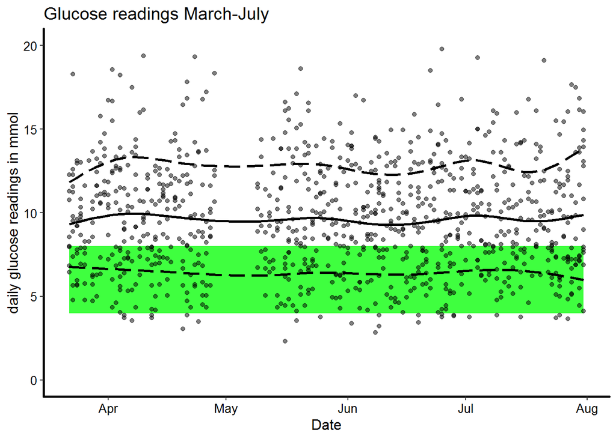

```r
pre_change_2016%>%
  ggplot(aes(x=Day, y=glucose_reading))+ #specify which variable I want on which axis
  geom_rect(aes(xmin=min(Day), #add a box for the target glucose range
                xmax=max(Day), #using min(variable on the x-axis) and max(variablye on the y axis saves you having to adjust the values by hand in case you subset the data)
                ymin=4,
                ymax=8),
            fill="green",
            alpha=.007)+
  geom_point(alpha=.5)+ #plot every individual gucose reading as a point
  geom_smooth(aes(y=daily_mean), #plot the daily mean
              color = "black",se=FALSE)+
  geom_smooth(aes(y=daily_mean+daily_sd), #plot the upper standard deviation
              se=FALSE, color="black", lty=5)+
  geom_smooth(aes(y=daily_mean-daily_sd),
              se=FALSE, color="black", lty=5)+ #plot the lower standard deviation
  ylim(0.0, 20.0)+ #set the limits of the y-axis
  labs(y="daily glucose readings in mmol", # set axis labels and title
       x="Date",
       title = "Glucose readings March-July")+
  t1 #add our theme
```

This visualises the reason for starting this project: daily variability of glucose readings is pretty high, and the mean is consistently higher than the target range.

### Faceting: zoom in to an average day each month

We might want to know how these daily readings are distributed, so let’s take a quick look at the days I’ve recorded, faceted by each month.

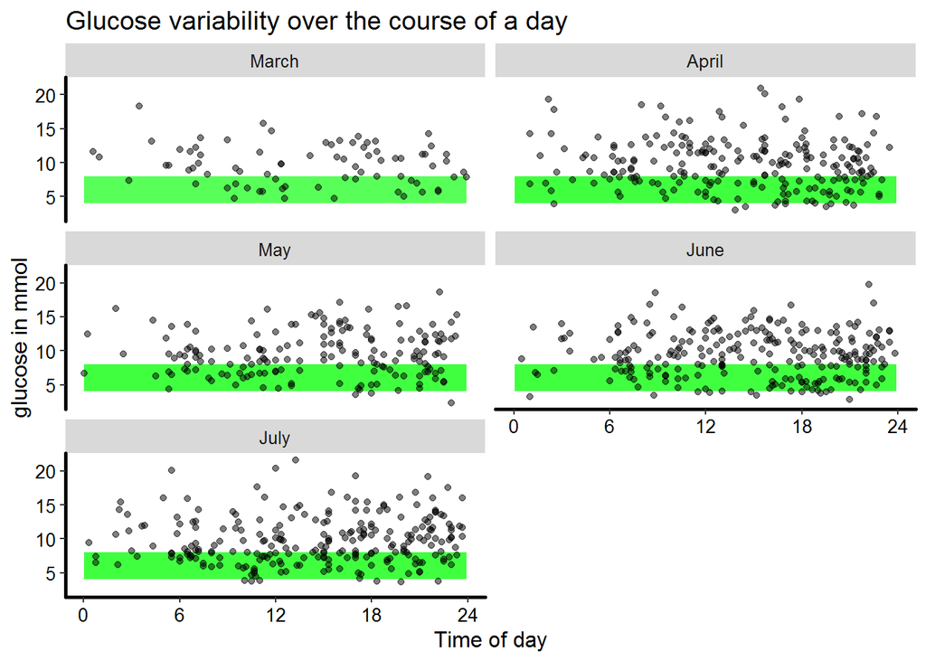

```r
pre_change_2016%>%
  mutate(month = month(Day, label=TRUE, abbr=FALSE))%>%
  subset(glucose_reading = !is.na(glucose_reading))%>%
  ggplot(aes(x=as.numeric(time)/3600, y=glucose_reading))+ #in order to use time on the x-axis, we need to convert it to a numeric value
  geom_rect(aes(xmin=min(as.numeric(time)/3600), #add a box for the target glucose range
                xmax=max(as.numeric(time)/3600),
                ymin=4,
                ymax=8),
            fill="green",
            alpha=.007)+
  geom_point(alpha=0.5)+
  scale_x_continuous(breaks=seq(0,24,6))+ # specify where the x-axis ticks are ti be placed: ranging from 0 to 24, one mark on every 6th number
    labs(y="glucose in mmol", # set axis labels and title
       x="Time of day",
       title = "Glucose variability over the course of a day")+
   t1+
  facet_wrap(~month, ncol = 2) #tell ggplot to create one facet for each month in which I recorded date, and to print these facets in two columns (i.e. two next to each other)
```

The combination of lubridate() and dplyr() is great, because we could just as well break down the data by week, or pick out individual days or date ranges.

### What causes the high variability?

But let’s get back to the practical problem: What causes this high glucose variability?

[figure not shown]

There are many possible predictors of both glucose variability and insulin sensitivity, and I could plot them all out. Remember the list the Diabetes team at the Royal Infirmary give their patients? Plenty of predictor variables (and complex combinations thereof) to consider.

Let’s look at some possibilities, that also happen to represent different types of plots:

- daytype (categorical, unordered)
- hormones? (ordered factor, days of the cycle)
- amount of exercise in any given day, measured in kcal_burned
- amount of carbs (as macronutrient ratio)

[figure not shown]

For the plots I will show below, glucose in mmol/l is given on the y-axis, and the potential predictor is plotted on the x-axis.

#### Visualising variability by type of day

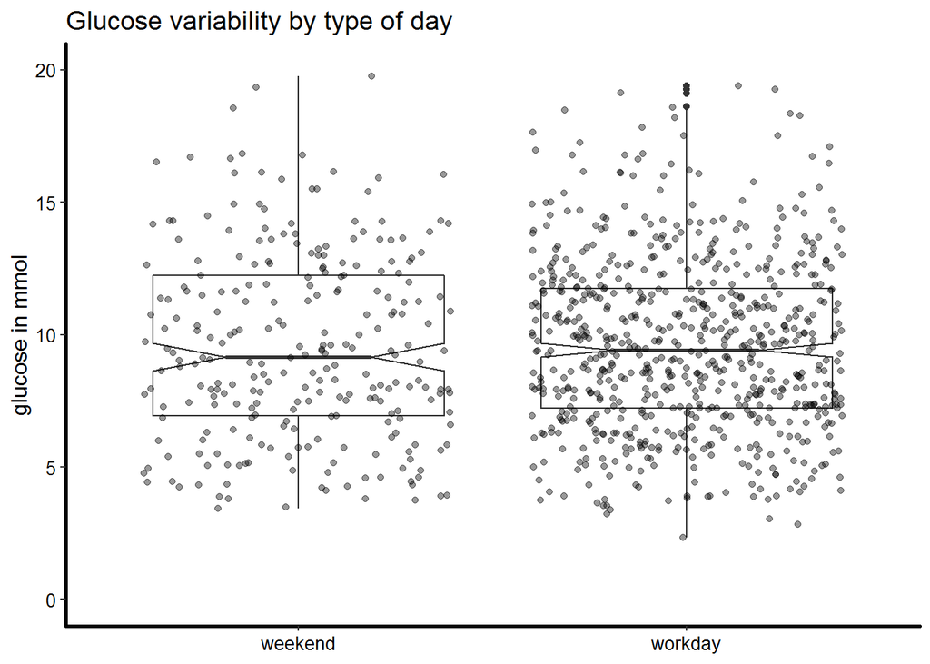

```r
pre_change_2016%>%
  drop_na(glucose_reading)%>%
  ggplot(aes(x=day_type, y=glucose_reading))+
  geom_boxplot(notch = TRUE)+ #create boxplots as base layer, containing mean and sd; set "notch=TRUE" to get a visual impression whether there is a statistically significant difference between the means of the two groups
  geom_jitter(alpha=0.4)+ #plot each individual glucose reading as its own point, geom_jitter() spreads them to avoid overlap (as opposed to geom_point used in the previous plot)
  ylim(0.0, 20.0)+ #set the limits of the y-axis
  labs(y="glucose in mmol", # set axis labels and title
       x=NULL,
       title = "Glucose variability by type of day")+
   t1
```

No pattern recognisable

#### visualising variability by cycle day

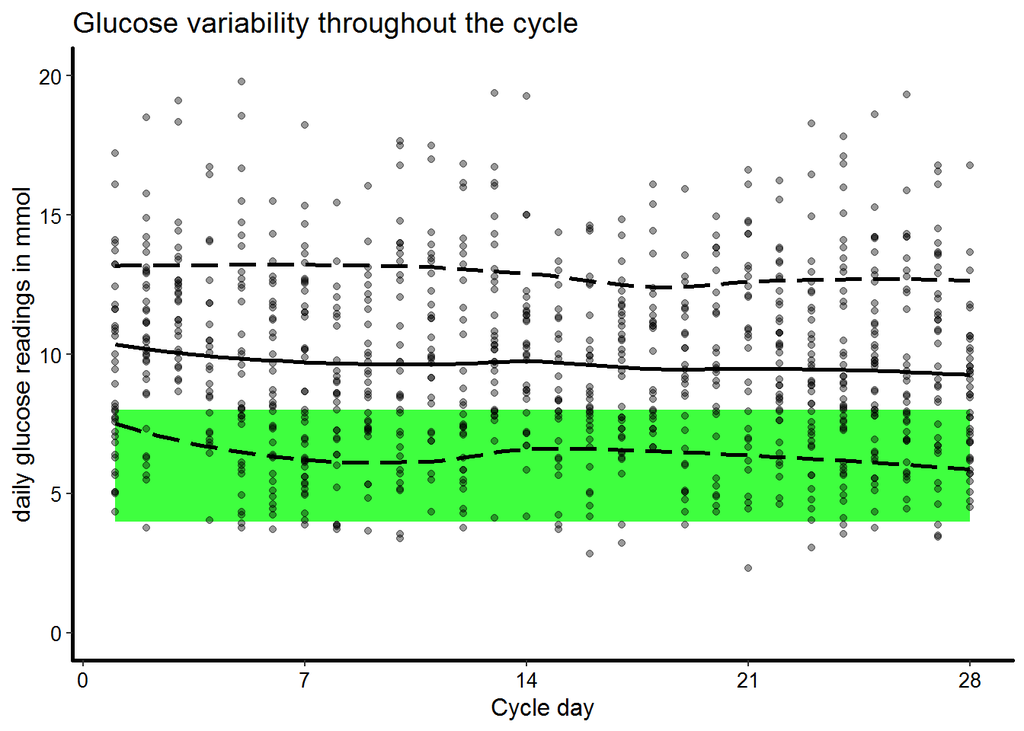

```r
pre_change_2016%>%
  drop_na(glucose_reading)%>%
  group_by(Day)%>%
  ggplot(aes(x=cycle_day, y=glucose_reading))+
  geom_rect(aes(xmin=1, #add a box for the target glucose range
                xmax=28,
                ymin=4,
                ymax=8),
            fill="green",
            alpha=.007)+
  geom_point(alpha=.4)+
   geom_smooth(aes(y=daily_mean), #plot the daily mean
              color = "black",
              se=FALSE)+
  geom_smooth(aes(y=daily_mean+daily_sd), #plot the upper standard deviation
              se=FALSE,
              color="black",
              lty=5)+
  geom_smooth(aes(y=daily_mean-daily_sd),
              se=FALSE,
              color="black",
              lty=5)+
  ylim(0.0, 20.0)+ #set the limits of the y-axis
  labs(y="daily glucose readings in mmol", # set axis labels and title
       x="Cycle day",
       title = "Glucose variability throughout the cycle")+
  scale_x_continuous(breaks=seq(0,28,7))+ # specify where the x-axis ticks are ti be placed: ranging from 0 to 28, one mark on every 7th tick
  t1
```

No clear pattern recognisable

#### visualising variability relative to exercise

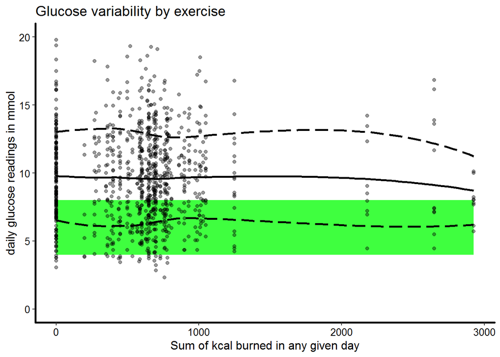

```r
pre_change_2016%>%
  group_by(Day)%>%
  drop_na(glucose_reading)%>%
  mutate(daily_mean = mean(glucose_reading), #calculate the daily mean
         daily_sd = sd(glucose_reading))%>% #calculate the daily standard deviation
  ggplot(aes(x=total_kcal_burned, y=glucose_reading))+
  geom_rect(aes(xmin=0, #add a box for the target glucose range
                xmax=max(total_kcal_burned),
                ymin=4,
                ymax=8),
            fill="green",
            alpha=.007)+
  geom_point(alpha=.4)+
   geom_smooth(aes(y=daily_mean), #plot the daily mean
              color = "black",
              se=FALSE)+
  geom_smooth(aes(y=daily_mean+daily_sd), #plot the upper standard deviation
              se=FALSE,
              color="black",
              lty=5)+
  geom_smooth(aes(y=daily_mean-daily_sd),
              se=FALSE,
              color="black",
              lty=5)+
  ylim(0.0, 20.0)+ #set the limits of the y-axis
  labs(y="daily glucose readings in mmol", # set axis labels and title
       x="Sum of kcal burned in any given day",
       title = "Glucose variability by exercise")+
  #scale_x_continuous(breaks=seq(0,28,7))+ # specify where the x-axis ticks are ti be placed: ranging from 0 to 28, one mark on every 7th tick
  t1
```

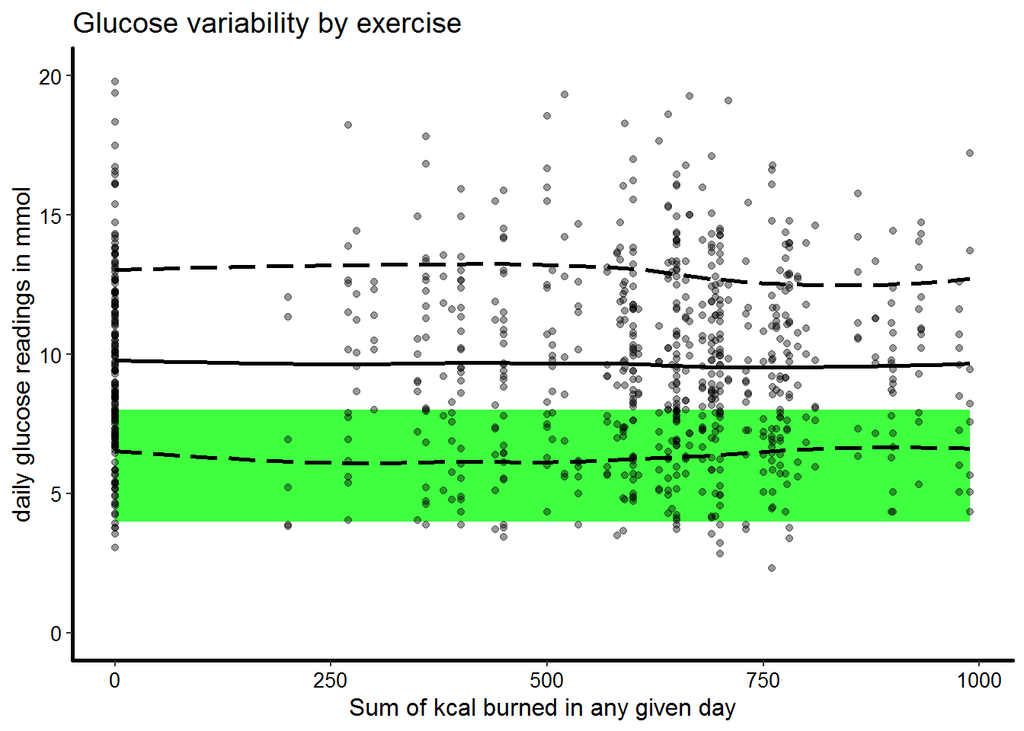

```r
pre_change_2016%>%
  group_by(Day)%>%
  drop_na(glucose_reading)%>%
  subset(total_kcal_burned<=1000)%>% #SUBSET as described above
  ggplot(aes(x=total_kcal_burned, y=glucose_reading))+
  geom_rect(aes(xmin=0, #add a box for the target glucose range
                xmax=max(total_kcal_burned),
                ymin=4,
                ymax=8),
            fill="green",
            alpha=.007)+
  geom_point(alpha=.4)+
   geom_smooth(aes(y=daily_mean), #plot the daily mean
              color = "black",
              se=FALSE)+
  geom_smooth(aes(y=daily_mean+daily_sd), #plot the upper standard deviation
              se=FALSE,
              color="black",
              lty=5)+
  geom_smooth(aes(y=daily_mean-daily_sd),
              se=FALSE,
              color="black",
              lty=5)+
  ylim(0.0, 20.0)+ #set the limits of the y-axis
  labs(y="daily glucose readings in mmol", # set axis labels and title
       x="Sum of kcal burned in any given day",
       title = "Glucose variability by exercise")+
  t1
```

#### visualising variability relative to carb intake

Let’s be adventurous and create a new continuous variable: the percentage of daily calories accounted for by carbohydrates. Again, we do some data prep and create our new variable, and then we pipe it into a plot. Because I am primarily interested in reducing the variability, I will plot the standard deviation rather than individual glucose readings on the y-axis

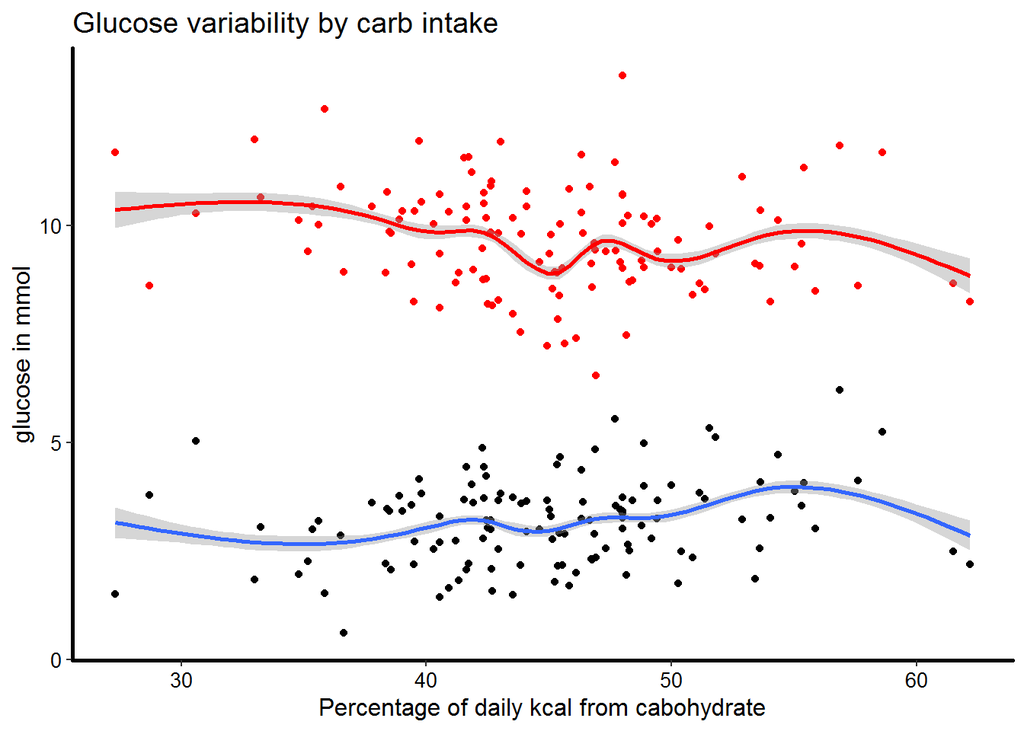

```r
pre_change_2016%>%
  group_by(Day)%>%
  ggplot(aes(x=carb_ratio, y=daily_sd))+
  geom_point()+
  geom_smooth()+
  geom_point(aes(y=daily_mean), color="red")+
  geom_smooth(aes(y=daily_mean), colour="red")+
  labs(y="glucose in mmol", # set axis labels and title
       x="Percentage of daily kcal from cabohydrate",
       title = "Glucose variability by carb intake")+
  t1
```

RED: Mean glucose reading in any given day

BLACK & BLUE: Standard deviation in any given day

There seem to be two complementary trends:

1. lower carb intake = higher mean
2. lower carb intake = lower standard deviation

Because both these observations make logical sense, I decided to start an intervention-based study and cut the carb-intake. This is captured in the “post_change2016” part of the dataset.

We can re-create the plot given above with the full dataset, to see how these trends develop on days with lower carb intakes.

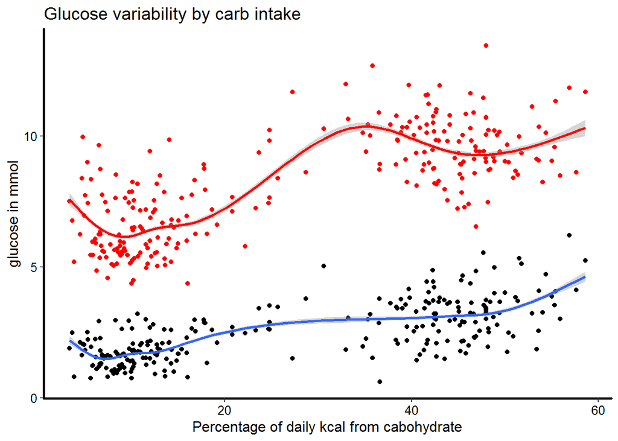

```r
data_2016%>%
  group_by(Day)%>%
  subset(carb_ratio>1&carb_ratio<60)%>%
  ggplot(aes(x=carb_ratio, y=daily_sd))+
  geom_point()+
  geom_smooth()+
  geom_point(aes(y=daily_mean), color="red")+
  geom_smooth(aes(y=daily_mean), colour="red")+
  labs(y="glucose in mmol", # set axis labels and title
       x="Percentage of daily kcal from cabohydrate",
       title = "Glucose variability by carb intake")+
  t1
```

### Visualisation challenge

So, here’s a ggplot challenge: How can I best display the change over time in daily mean glucose and variability, and visualise that this is dependent on the level of carb intake? Essentially, I want to combine the plot just shown with the initial one that shows glucose variability from March to July.

This is what I want:

- Date on the x-axis, from March to December (i.e. using the full 2016 dataset)
- glucose in mmol on the y-axis
- the green box for the target range
- the smooth trend line to represent the development of daily mean glucose
- smooth lines to represent the development of the upper and lower standard deviation boundaries
- an “average glucose reading” point (or other visual) that represents how carb-heavy that day was.

So let’s do this - the first part of the plot is exactly what I used in the first plot.

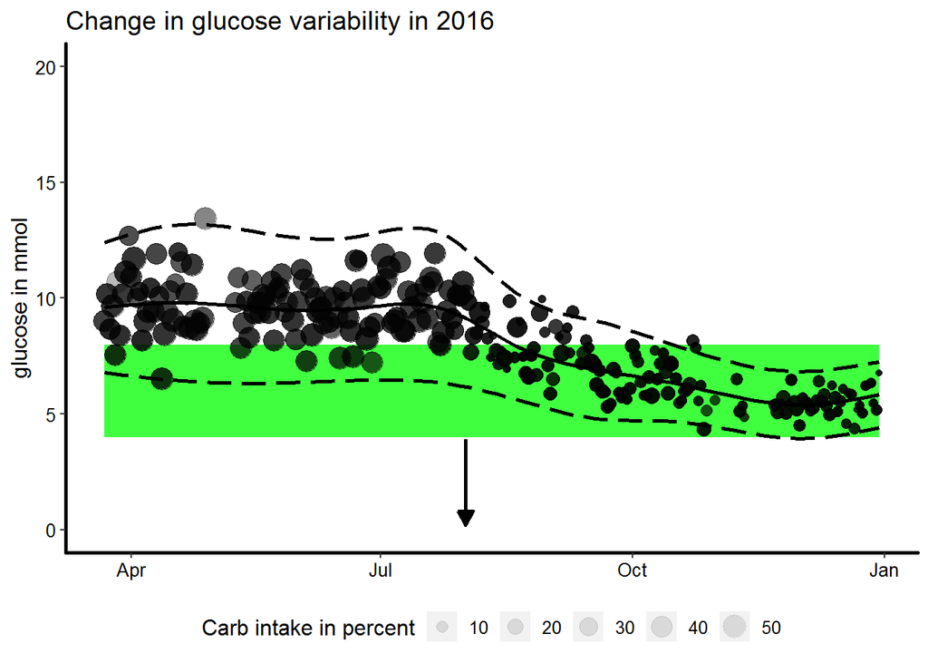

```r
data_2016%>%
  group_by(Day)%>% # I want to look at the data by day, and group_by() allows me to do so
 # subset(Day > ymd(20160601))%>% #subset the "pre-change" data to June&July, given that we have already seen the trend was stable from March to July
  # now we can feed the data into the visualisation
  subset(carb_ratio>0 & carb_ratio<60)%>% #exclude days with incomplete entries that result in a misleadingly high carb ratio or zero
  ggplot(aes(x=Day, y=daily_mean))+
  geom_rect(aes(xmin=min(Day), #add a box for the target glucose range
                xmax=max(Day),
                ymin=4,
                ymax=8),
            fill="green",
            alpha=.007)+
  geom_point(aes(size=carb_ratio), alpha=.1)+
  scale_size("Carb intake in percent")+
  geom_smooth(aes(y=daily_mean), #plot the daily mean
              color = "black",
              se=FALSE)+
  geom_smooth(aes(y=daily_mean+daily_sd), #plot the upper standard deviation
              se=FALSE,
              color="black",
              lty=5)+
  geom_smooth(aes(y=daily_mean-daily_sd),
              se=FALSE,
              color="black",
              lty=5)+
  ylim(0.0, 20.0)+ #set the limits of the y-axis
  labs(y="glucose in mmol", # set axis labels and title
       x=NULL,
       title = "Change in glucose variability in 2016")+
   t1+
  annotate("segment",
           x = ymd(20160801), xend = ymd(20160801), y = 3.9, yend = 0.2,
           colour="black", size=1,
           arrow=arrow(length = unit(.3, "cm"), type="closed"))
```

This is pretty neat - the arrow points to the 1st of August, when I started the intervention-based study, and the trend lines and daily means show three things:

- variance goes down immediately and becomes very low by the end of the year
- the mean gradually moves to the centre of the target range, getting it there takes roughly from August to October (learning curve)
- by October, both the mean and the variance are within the target range

This is the life-changing impact of a stats project: I went from messy glucose levels and a lot of frustration before the analysis to identifying the factor that most strongly correlated with variability, and by manipulating it decreased variability and frustration.

# Beyond the first eight months: use existing logs, merge files

Because it gets rather tedious to keep logging everything by hand, I decided to try and pull together data from different sources I had - the different join() functions within the tidyverse are great for that.

I can download and merge data on insulin given and glucose measured, but need to keep a manual log of food and exercise at the moment. Because that is still fairly tedious, the next steps I’d like to implement are:

- find a food and exercise tracker that allows me to download the data as a *.csv and integrate it in the analysis workflow
- figure out cyclical patterns in insulin resistance/ sensitivity
- indicators are: increase in insulin given unrelated to food (or change in ratio of calories to bolus)
- higher standard deviation
- more extreme glucose excursion following meal